# Exercise 10

Matthew Reynolds

2023-04-19

**Question:**  
This question should be answered using the Weekly data set, which is part of the ISLR package. This data is similar in nature to the Smarket data from this chapter’s lab, except that it contains 1,089 weekly returns for 21 years, from the beginning of 1990 to the end of 2010.

**A)**

```r
summary(Weekly)
```

```
##       Year           Lag1               Lag2               Lag3
##  Min.   :1990   Min.   :-18.1950   Min.   :-18.1950   Min.   :-18.1950
##  1st Qu.:1995   1st Qu.: -1.1540   1st Qu.: -1.1540   1st Qu.: -1.1580
##  Median :2000   Median :  0.2410   Median :  0.2410   Median :  0.2410
##  Mean   :2000   Mean   :  0.1506   Mean   :  0.1511   Mean   :  0.1472
##  3rd Qu.:2005   3rd Qu.:  1.4050   3rd Qu.:  1.4090   3rd Qu.:  1.4090
##  Max.   :2010   Max.   : 12.0260   Max.   : 12.0260   Max.   : 12.0260
##       Lag4               Lag5              Volume            Today
##  Min.   :-18.1950   Min.   :-18.1950   Min.   :0.08747   Min.   :-18.1950
##  1st Qu.: -1.1580   1st Qu.: -1.1660   1st Qu.:0.33202   1st Qu.: -1.1540
##  Median :  0.2380   Median :  0.2340   Median :1.00268   Median :  0.2410
##  Mean   :  0.1458   Mean   :  0.1399   Mean   :1.57462   Mean   :  0.1499
##  3rd Qu.:  1.4090   3rd Qu.:  1.4050   3rd Qu.:2.05373   3rd Qu.:  1.4050
##  Max.   : 12.0260   Max.   : 12.0260   Max.   :9.32821   Max.   : 12.0260
##  Direction
##  Down:484
##  Up  :605
##
##
##
##
```

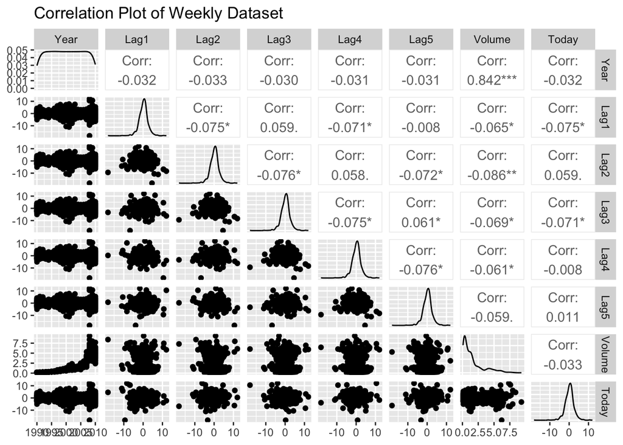

```r
ggpairs(Weekly,
        columns = 1:8,
        title = "Correlation Plot of Weekly Dataset",
        upper = list(wrap(continuous = "cor", funcVal = cor, method = "pearson")),
        lower = list(wrap(continuous = "smooth", funcVal = smooth, method = "lm")),
        diag = list(continuous = "density"),
        axisLabels = "show"
        )
```

I would say there seems to be a pattern between our Year and Volume which looks like it increases quadraticly. Otherwise, everything else seems rather Blob-like.

**B)**

```r
fit <- glm(Direction ~ Lag1 + Lag2 + Lag3 + Lag4 + Lag5 + Volume, data = Weekly, family = binomial)
summary(fit)
```

```
##
## Call:
## glm(formula = Direction ~ Lag1 + Lag2 + Lag3 + Lag4 + Lag5 +
##     Volume, family = binomial, data = Weekly)
##
## Deviance Residuals:
##     Min       1Q   Median       3Q      Max
## -1.6949  -1.2565   0.9913   1.0849   1.4579
##
## Coefficients:
##             Estimate Std. Error z value Pr(>|z|)
## (Intercept)  0.26686    0.08593   3.106   0.0019 **
## Lag1        -0.04127    0.02641  -1.563   0.1181
## Lag2         0.05844    0.02686   2.175   0.0296 *
## Lag3        -0.01606    0.02666  -0.602   0.5469
## Lag4        -0.02779    0.02646  -1.050   0.2937
## Lag5        -0.01447    0.02638  -0.549   0.5833
## Volume      -0.02274    0.03690  -0.616   0.5377
## ---
## Signif. codes:  0 '***' 0.001 '**' 0.01 '*' 0.05 '.' 0.1 ' ' 1
##
## (Dispersion parameter for binomial family taken to be 1)
##
##     Null deviance: 1496.2  on 1088  degrees of freedom
## Residual deviance: 1486.4  on 1082  degrees of freedom
## AIC: 1500.4
##
## Number of Fisher Scoring iterations: 4
```

It would appear that Lag2 is the only one to have a P-Value lower than 0.05, so I would say it’s the only significant one.

**C)**

```r
predicted <- predict(fit, type = "response")
predicted_direction <- ifelse(predicted > 0.5, "Up", "Down")
confusion_df <- data.frame(Actual = Weekly$Direction, Predicted = predicted_direction)
confusion_matrix <- t(table(confusion_df))
print(confusion_matrix)
```

```
##          Actual
## Predicted Down  Up
##      Down   54  48
##      Up    430 557
```

```r
overall_accuracy <- sum(diag(confusion_matrix)) / sum(confusion_matrix)
cat("Overall Fraction of Correct Predictions:", overall_accuracy, "\n")
```

```
## Overall Fraction of Correct Predictions: 0.5610652
```

My True Positive was 557, meaning it predicted UP correctly. My False Positive was 430, meaning it predicted UP incorrectly. My True Negative was 54 meaning it predicted Down correctly. And My False Negative was 48 meaning it predicted Down incorrectly. My model was correct for ~56% of its predictions.

**D)**

```r
train_data <- Weekly[Weekly$Year <= 2008, ]
test_data <- Weekly[Weekly$Year > 2008, ]
model <- glm(Direction ~ Lag2, data = train_data, family = binomial)
predictions <- predict(model, newdata = test_data, type = "response")
predicted_directions <- ifelse(predictions > 0.5, "Up", "Down")
confusion_matrix <- table(test_data$Direction, predicted_directions)
overall_accuracy <- sum(diag(confusion_matrix)) / sum(confusion_matrix)
confusion_matrix <- t(confusion_matrix)
cat("Confusion Matrix:\n")
```

```
## Confusion Matrix:
```

```r
print(confusion_matrix)
```

```
##
## predicted_directions Down Up
##                 Down    9  5
##                 Up     34 56
```

```r
cat("\nOverall Fraction of Correct Predictions:", overall_accuracy)
```

```
##
## Overall Fraction of Correct Predictions: 0.625
```

The model correctly predicts the weekly trend only 62.5% of the time.

**I)**

```r
train_data <- Weekly[Weekly$Year < 2009, ]
test_data <- Weekly[Weekly$Year >= 2009, ]

predictors <- c("Lag2", "Lag1", "Lag3", "Lag4", "Lag5", "Volume")

# Initialize best_model, best_variables, and best_accuracy
best_model <- NULL
best_variables <- NULL
best_accuracy <- 0

#brute force it
for (i in 1:length(predictors)) {
  for (j in 1:length(predictors)) {
    if (i == j) next

    predictors_current <- c(predictors[i], predictors[j])
    model <- glm(Direction ~ ., data = train_data[, c(predictors_current, "Direction")], family = "binomial")

    predicted_directions <- ifelse(predict(model, test_data) > 0.5, "Up", "Down")
    confusion_matrix <- table(predicted_directions, test_data$Direction)
    overall_accuracy <- sum(diag(confusion_matrix)) / sum(confusion_matrix)

    if (overall_accuracy > best_accuracy) {
      best_model <- model
      best_confusion_matrix <- t(confusion_matrix)
      best_accuracy <- overall_accuracy
      best_variables <- paste(predictors_current, collapse = ", ")
    }
  }
}

# output
cat("Best Model:\n")
```

```
## Best Model:
```

```r
print(best_model)
```

```
##
## Call:  glm(formula = Direction ~ ., family = "binomial", data = train_data[,
##     c(predictors_current, "Direction")])
##
## Coefficients:
## (Intercept)         Lag2         Lag5
##     0.20741      0.05652     -0.02973
##
## Degrees of Freedom: 984 Total (i.e. Null);  982 Residual
## Null Deviance:       1355
## Residual Deviance: 1349  AIC: 1355
```

```r
cat("Best Confusion Matrix:\n")
```

```
## Best Confusion Matrix:
```

```r
print(best_confusion_matrix)
```

```
##       predicted_directions
##        Down Up
##   Down   41  2
##   Up     55  6
```

```r
cat("Variables used in the best-performing model:", best_variables, "\n")
```

```
## Variables used in the best-performing model: Lag2, Lag5
```

```r
cat("Best Overall Fraction of Correct Predictions:", best_accuracy)
```

```
## Best Overall Fraction of Correct Predictions: 0.4519231
```